# Giddens论高级社会的阶级结构

GingLam

2018-03-28

#### 一、韦伯主义的批评

**（一）韦伯的阶级理论是英文世界了解德国社会学阶级理论的窗口，但韦伯分析的真实意义时常被误读。**

**（二）韦伯对马克思阶级理论的批评与超越：**

1、韦伯对马克思阶级概念的第一个超越是清晰区分了阶级、地位团体（status）和政党（party）；

2、韦伯强调的是一种关于阶级的多元主义概念，并进一步区分：

- 所有权阶级（ownership class；Besizklassen）：这是食租者（rentier），所拥有的财产是用来产生回报的。
- 营生阶级（acquisition class；Erwerbsklassen）：这是经营者（entrepreneurial），提供服务在市场上加以出售。

3、韦伯认为无产者（propertyless）根据其所垄断的市场技能（monopolisation of marketable skills）可以是分化的（differentiated）。

4、韦伯认为中间阶级处于“正向特权阶级（有产阶级）”positively privileged class（the propertied）和“负向特权阶级（既无产亦无市场技能）”negatively privileged class之间。后者和无产阶级一样，但和具备市场价值的无产阶级也不同。

5、韦伯认为阶级是作为一个客观存在的属性来影响人们的生活机会，并且在特定的情况下阶级不可能发展成为一个主观上自我意识得到的共同体。而地位群体（status groups；stande）则通常是以共同体的形式而存在的。

6、韦伯认为权力在某种意义上不是第三个社会分层的维度，阶级、地位团体和政党全部都属于“权力分配现象”。

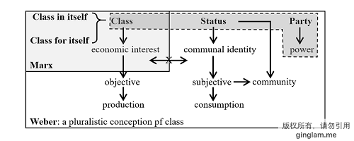

7、韦伯还提出社会阶级（social class）的概念

- 社会阶级：由一系列阶级处境（class situations）所构成，这些阶级处境与人们的共同流动机会联系在一起，不管是代内的个人职业生涯还是跨代之间。
- 社会阶级与地位团体的概念更接近一些，它仅描述一类与社会交换相联系的阶级处境。
- 在资本主义社会存在四种主要的社会阶级群组：
- 手工工人阶级 （manual working class）
- 小布尔乔亚（the petty bourgeoisie）
- 无产白领工人（propertyless white-collar workers）
- 通过财产和教育获得特权的上层阶级（those privileged through property and education）

**这些群组中最重要的工人阶级、无产的中间阶级和有产的上层阶级。**

- 韦伯和马克思的观点一致，即随着资本主义社会日益走向成熟，小布尔乔亚这一社会阶级的类别将会日渐缩小，它们可能会被吸纳到熟练手工工人阶级或非手工劳动的领薪工人阶级当中。
- 韦伯认为小布尔乔亚缩小的同时，无财产的中产阶级会随着资本主义社会演进而得到最大程度的扩张。

#### 二、对阶级理论的再思考。

**（一）对阶级这一概念进行重新的概念化**

1、马克思把“无产者”作为一个内部没有分化的阶级类别是不妥当的，达伦多夫建议把注意力放在财产（property）和权威（authority）之间的关系上。

2、韦伯对财产这个概念的加以转化（inverted）和概念化（generalised），认为财产并不是指各种实物特性（characteristics of physical objects），而是指与这些实物相关联的权利（rights），紧接着这些权利赋予实物所有者以特定的能力（capacities）。

3、在市场中，作为私有财产的资本的重要意义在于，资本所有者因为拥有了资本而被授予特定的、非常明确的能力。

4、马克思的“无产”是含糊的说法，因为工人也拥有自身作为劳动力这样一个待售卖的财产，尽管在竞争性市场的议价中处于相对不利的地位，但雇主人需要对工资劳动者的要求给予一定的关注，防止他们通过罢工等集体性行动撤出（collective withdrawal of labour）对雇主进行惩罚。无论是表现为资本还是表现为劳动力的“财产”，都是一种特定的、决定市场议价结果的行动能力。

5、Giddens提出市场能力（market capacity）：这是个体带到议价场合中的所有相关属性形式。

**（二）从生产性劳动力到能力性财产，从阶级处境到市场处境**

1、一个社会中财产总是集中在少数人的手中，而社会中的绝大多数人都是在市场上售卖其劳动力的工资劳动者。

2、但生产性劳动力不是同质化的技能水准，市场能力存在分化，且分化水平取决于个体所“拥有”的能力的稀缺程度，同时这一能力可以在市场上加以售卖。

**马克思认为现代技术会把生产性操作转化为同质的技能水准，这是他推理的前提。**

3、韦伯指出拥有市场所承认的技能，包括教育资质在内，是影响个体的市场能力的最主要的因素。市场能力的分化有可能被个体用来获取工资之外的其他经济回报（如就业安全度、职业晋升前景和养老金）。

4、在竞争型资本主义的市场结构中，所有人都卷入到争夺稀缺性回报的利益角逐之中，其中的利益冲突由各种分化的市场能力而产生。这里还存在财产和非财产形式的市场能力。

5、韦伯采用“市场处境”的概念避开了马克思阶级分析框架的缺点，从而从纷繁复杂的市场关系冲突中辩析出结构化存在的阶级。

**马克思对“自在阶级”与“自为阶级”的区分是想理解在资本主义社会中，革命性的阶级意识是如何形成的，同时又是如何被推进的。**

6、Giddens的方案

过去，阶级这个术语的使用可以分为经济范畴（economic category）和社会分组（social groupings）。但阶级理论的主要问题不是阶级概念本身，而是阶级关系的结构化（structuration of class relationship）。

- 阶级不是一个拥有明确边界的特定实体（entity）；
- 阶级区别于阶层（stratum），阶级研究不同于阶层研究（study of stratification）。阶级难以通过清晰的名义测量测度加以描述。
- 阶级理论与精英理论（精英对应着大众）也十分不同。

#### 三、着眼阶级关系的结构化。

**（一）阶级关系的两类结构化类型**

1、间接的结构化（mediate structuration）：考察市场能力与形成可辨识社会群组的阶级之间的理论元素。

2、直接的结构化（proximate structuration）：考察直接形成阶级的理论元素。

**（二）间接阶级关系中的三种最重要的市场能力，其决定着流动集会的封闭或开放程度**

1、在生产方式中的财产所有权（ownership of property in the means of ptoduction）；

2、拥有教育或技术文凭（possession of educational or technical qualification）；

3、占有手工劳动力（possession of manual labour-power）。

**这三种能力联系在一起组成了三大阶级的基本体系：上层阶级、中间阶级、下层阶级。**

**（三）直接接关系中的结构化过程来源**

1、生产性企业中的劳动分工（the division of labour within the productive enterprise）;

劳动分工区分除了手工劳动者和非手工劳动者，连带着产生了工作环境是手工劳动者和管理层员工的处境，形成实际的分隔。

2、企业中的权威关系（the authority relationships within the enterprise）；

劳动分工是在下层阶级中制造分化，财产所有权是在中上层阶级中制造分化，形成了所有权和控制权相互分离。

3、分配性分组（distributive groupings）。

分配性分组是消费领域而非生产领域，其生成不仅是建立在收入分化，也建立在荣誉和声望等一系列指标中。 直接结构化和间接结构化相互结合，及其产生的三足鼎立的阶级结构，在资本主义社会具有普遍性。

**（三）阶级认识（class awareness）和阶级意识（class consciousness）**

1、阶级认识：只要阶级是一个结构化的现象，那么同属一个阶级的人们之间就会存在一个共同的认识以及对类似态度和信仰的共同接受，并且这一共同的认识和接受将与一个共同的生活方式直接联系起来。阶级认识拒绝承认阶级的存在或拒绝承认阶级的现实。

2、阶级意识：一种态度和信仰的阶级归属感，使人们意识到这个社会还存在其他不同态度、信仰和生活方式不同的阶级。